# Usando chilemapas con tmap

Luis A. Apiolaza

2019-12-12

# Introducción

[tmap](https://cran.r-project.org/web/packages/tmap/index.html) (thematic maps) es un paquete para producir mapas con temas consistentes y acceder a elementos básicos de cartografía, como escalas, sistemas de orientación, etc. `tmap` tiene algunas similaridades con `ggplot2` pero ha sido diseñado para la producción específica de mapas.

La [vignette](https://cran.r-project.org/web/packages/tmap/vignettes/tmap-getstarted.html) de `tmap` presenta una introducción al uso del paquete, mientras que el [capítulo 8](https://geocompr.robinlovelace.net/adv-map.html) del libro ‘Geocomputation with R’ entrega algunos ejemplos más avanzados.

El mínimo de paquetes para producir mapas incluye:

- `chilemapas`, que entrega la geometría y nombres de comunas, provincias y regiones de Chile,
- `dplyr` para manipular datos de diferentes fuentes (pr ejemplo, filtrar, combinar, etc), y
- `tmap` para crear la representación gráfica del mapa.

# Población de adultos mayores en la Región de los Ríos

Al igual que en la vignette de uso básico de `chilemapas`, vamos a mostrar la Region de los Ríos, agregar los nombres de las comunas y colorearlas de acuerdo al número de habitantes que son adultos mayores (65 años o más).

Para entender mejor la primera parte del código, es conveniente saber que la variable edad del dataset censo_2017_comunas es un factor en que los adultos mayores ocupan del nivel 14 en adelante.

## Graficar comunas

```r
library(chilemapas)
library(dplyr)
library(tmap)

# Muestra por que as.integer(edad) >= 14 es lo que necesitamos
levels(censo_2017_comunas$edad)
```

```
##  [1] "0 a 4"     "10 a 14"   "15 a 19"   "20 a 24"   "25 a 29"
##  [6] "30 a 34"   "35 a 39"   "40 a 44"   "45 a 49"   "5 a 9"
## [11] "50 a 54"   "55 a 59"   "60 a 64"   "65 a 69"   "70 a 74"
## [16] "75 a 79"   "80 a 84"   "85 a 89"   "90 a 94"   "95 a 99"
## [21] "100 o mas"
```

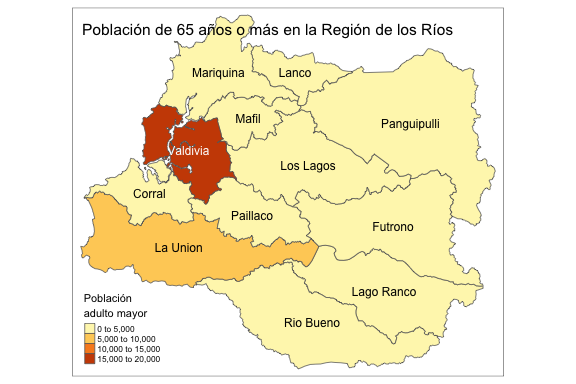

```r
# Para cada comuna calcula la suma de poblacion
# mayor o igual de 65
poblacion_adulto_mayor_comunas <- censo_2017_comunas %>%
  filter(as.integer(edad) >= 14) %>%
  group_by(codigo_comuna) %>%
  summarise(pob_adulto_mayor = sum(poblacion))

# Extrae del mapa de comunas todas las que pertenecen
# a la Region 14 (de los Rios)
comunas_los_rios <- mapa_comunas %>%
  filter(codigo_region == 14)

# Extrae los nombres de comunas de la Region 14
nombres_comunas <- codigos_territoriales %>%
  filter(codigo_region == 14)

# Une la geometria de las comunas, con sus nombres
# y poblacion mayor o igual de 65
comunas_los_rios <- comunas_los_rios %>%
  left_join(nombres_comunas) %>%
  left_join(poblacion_adulto_mayor_comunas)

tm_shape(comunas_los_rios) +
  tm_polygons(col = "pob_adulto_mayor", title = "Población\nadulto mayor") +
  tm_text(text = "nombre_comuna") +
  tm_layout(title = "Población de 65 años o más en la Región de los Ríos",
            scale = 0.75)
```

El mapa puede utilizar otro tema con poco código adicional. Por ejemplo, el tema *cobalt*:

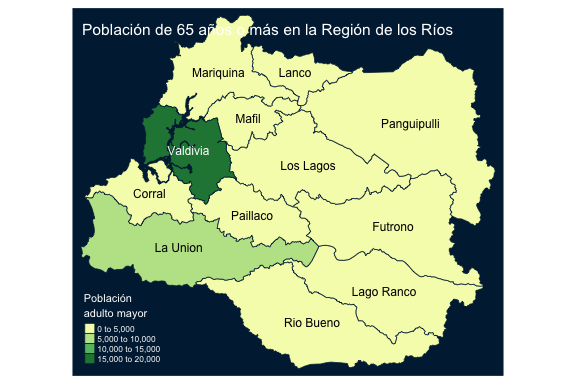

```r
tm_shape(comunas_los_rios) +
  tm_polygons(col = "pob_adulto_mayor", title = "Población\nadulto mayor") +
  tm_text(text = "nombre_comuna") +
  tm_style("cobalt") +
  tm_layout(title = "Población de 65 años o más en la Región de los Ríos",
            scale = 0.75)
```

O un tema más tradicional como el *classic*:

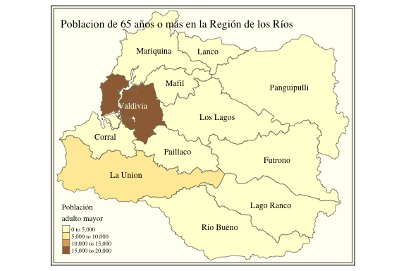

```r
tm_shape(comunas_los_rios) +
  tm_polygons(col = "pob_adulto_mayor", title = "Población\nadulto mayor") +
  tm_text(text = "nombre_comuna") +
  tm_style("classic") +
  tm_layout(title = "Poblacion de 65 años o más en la Región de los Ríos",
            scale = 0.75)
```